# Statistical Exploration of data

NWUDO CHIKAEZE FIDELIS JUNIOR

2023-02-01

Problem I: The following defects data collected from the last month’s inspection reports for a particular type of tank. Construct a Pareto diagram and discuss the results.

```r
library(qcc)
```

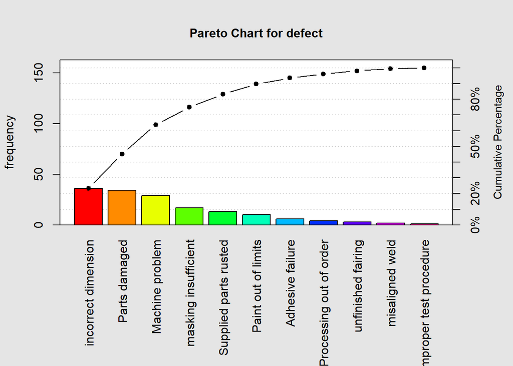

```
##
## Pareto chart analysis for defect
##                             Frequency   Cum.Freq.  Percentage Cum.Percent.
##   incorrect dimension      36.0000000  36.0000000  23.2258065   23.2258065
##   Parts damaged            34.0000000  70.0000000  21.9354839   45.1612903
##   Machine problem          29.0000000  99.0000000  18.7096774   63.8709677
##   masking insufficient     17.0000000 116.0000000  10.9677419   74.8387097
##   Supplied parts rusted    13.0000000 129.0000000   8.3870968   83.2258065
##   Paint out of limits      10.0000000 139.0000000   6.4516129   89.6774194
##   Adhesive failure          6.0000000 145.0000000   3.8709677   93.5483871
##   Processing out of order   4.0000000 149.0000000   2.5806452   96.1290323
##   unfinished fairing        3.0000000 152.0000000   1.9354839   98.0645161
##   misaligned weld           2.0000000 154.0000000   1.2903226   99.3548387
##   improper test procedure   1.0000000 155.0000000   0.6451613  100.0000000
```

```r
library(ggplot2)
library(tidyverse)
defect <- c(34, 29, 13, 17, 2, 4, 3, 36, 6, 10, 1)

names(defect) <- c('Parts damaged', 'Machine problem', 'Supplied parts rusted', 'masking insufficient', 'misaligned weld', 'Processing out of order', 'unfinished fairing', 'incorrect dimension', 'Adhesive failure', 'Paint out of limits', 'improper test procedure')

pareto.chart(defect, ylab = "frequency", cumperc = seq(0, 100, by = 10), col=rainbow(length(defect)))
```

The bars on the chart above depicts which solutions are more significant. The length of the bars represent the frequency and are arranged with the longest bars on the left and the shortest on the right. The linked dots are the cumulative sums.The cumulative sum for the last defect should always reach 100% on tghe right scale and we can see from the chart above that the cumulative sum for “improper test procedure” was 100%.

- The frequency of incorrect dimension is 36 | The cumulative frequency is 36.
- The frequency of parts damaged is 34 | The cumulative frequency is 70.
- The frequency of machine problem is 29 | The cumulative frequency is 99.
- The frequency of masking insufficient is 17 | The cumulative frequency is 116.
- The frequency of supplied parts rusted is 13 | The cumulative frequency is 129.
- The frequency of paints out of limit is 10 | The cumulative frequency is 139.
- The frequency of adhesive failure is 6 | The cumulative frequency is 145.
- The frequency of Processing out of order is 4 | The cumulative frequency is 149.
- The frequency of unfinished fairing is 3 | The cumulative frequency is 152.
- The frequency of misaligned weld is 2 | The cumulative frequency is 154.
- The frequency of improper test procedure is 1 | The cumulative frequency is 155.

PROBLEM II: Fifty soft drink bottles of a specific brand are collected from one day production and measured its net weight, which are given below: The specification limits for this brand are (16+0.5oz)

15.8 16.3 16.2 16.1 16.6 16.3 15.9 15.9 16.2 16.4 16.1 16.2 16.5 16.4 16.3 16.3 16.2 15.9 16.4 16.2 16.1 16.1 16.4 16.5 16.0 16.1 15.8 16.7 16.6 16.4 16.1 16.3 16.5 16.1 16.5 16.2 16.1 16.2 16.1 16.3 16.3 16.2 16.4 16.3 16.5 16.6 16.3 16.4 16.1 16.5

```r
B <- c(15.8, 16.3, 16.1, 16.3, 16.1, 16.1, 16.1, 16.2, 16.3, 16.6, 16.3, 15.9, 16.2, 16.2, 16.1, 15.8, 16.3, 16.1, 16.2, 16.3,
       16.2, 15.9, 16.5, 15.9, 16.4, 16.7, 16.5, 16.2, 16.4, 16.4, 16.1, 16.2, 16.4, 16.4, 16.5, 16.6, 16.1, 16.1, 16.3, 16.1, 16.6, 16.4, 16.3,
       16.2, 16.0, 16.4, 16.5, 16.3, 16.5, 16.5)
```

1)Estimate the mean and standard deviation

MEAN

```r
Mean <- sum(B) / length(B)
Mean
```

```
## [1] 16.258
```

STANDARD DEVIATION

```r
Var <- var(B)
SD <- sqrt(Var)
SD
```

```
## [1] 0.2119781
```

2. Draw a histogram with superimposing the specification limits. Interpret the histogram focussing on how to improve the process

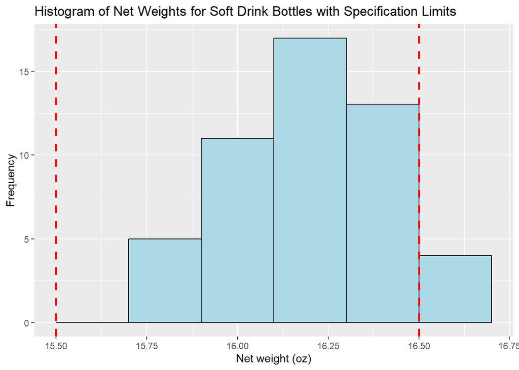

```r
ggplot(data.frame(B), aes(x = B)) +
  geom_histogram(binwidth=0.2, fill = "lightblue", color = 'black') +
  geom_vline(xintercept = c(15.5, 16.5), linetype="dashed", linewidth=1, color="red") +
  labs(x="Net weight (oz)", y="Frequency", title="Histogram of Net Weights for Soft Drink Bottles with Specification Limits")
```

- The histogram with the superimposed specification limits shows us that some of the bottles in the sample have a net weight that falls outside of the specification limits of (16 ± 0.5) oz. Any item that falls outside of this range would be considered as defective. There are a few bottles with a net weight above 16.5 oz. This suggests that the manufacturing process may not be consistent and may need to be improved to reduce the number of bottles outside of the specification limits.
3. Draw normal probability plot to justify your answer in (2)

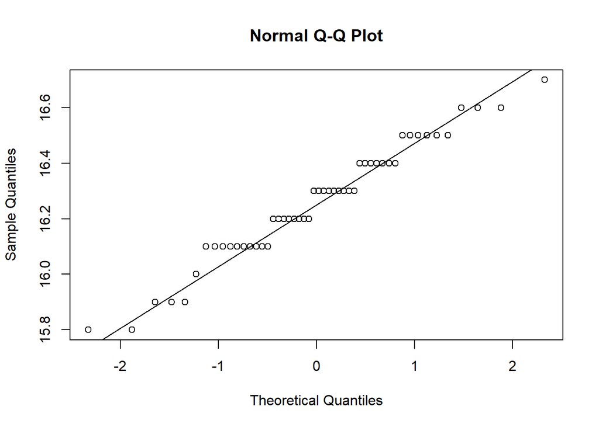

```r
qqnorm(B)
qqline(B)
```

4. Assuming the normality, estimate the sigma level of the process?

```r
Z_score <- min((16.5 - Mean)/SD, (Mean - 15.5)/SD)
Sigma_level <- Z_score + 1.5
Sigma_level
```

```
## [1] 2.641628
```

- With a sigma level of 2.641628, we can say that the process is not meeting customers expectations. A sigma level of 6 is generally considered a very good level of performance.
5. Estimate the percentage of soft drink bottle out side the lower specification and upper specification.

```r
range_min <- 15.5
range_max <- 16.5
sample_size <- 50


# Find the percentage of data points that fall outside of the specified range
outside_range <- pnorm(range_min, Mean, SD) + (1 - pnorm(range_max, Mean, SD))
percent_rejected <- outside_range * 100

print(paste0("Percentage of rejection: ", percent_rejected, "%"))
```

```
## [1] "Percentage of rejection: 12.6978967713574%"
```

6. Since the soft drink bottles fell outside the upper specification are quite large, it is decided to lower the process mean setting by 0.2 units. If you are the production manager, how many bottles of drink you need to produce to get 10000 accepted bottles, with new process mean setting, but same standard deviation?

```r
new_mean = 16.258 - 0.2  # the process mean reduced by 0.2 units

# Find the percentage of data points that fall outside of the specified range
outside_range <- pnorm(range_min, new_mean, SD) + (1 - pnorm(range_max, new_mean, SD))
percent_rejected <- outside_range * 100
percent_accepted <- 100 - percent_rejected

print(paste0("Percentage of acceptance: ", percent_accepted, "%"))
```

```
## [1] "Percentage of acceptance: 97.7231017779453%"
```

```r
print(paste0(round(10000/(percent_accepted/100)), " bottles need to be produced to get 10000 accepted bottles "))
```

```
## [1] "10233 bottles need to be produced to get 10000 accepted bottles "
```

PROBLEM III: The manager of the local hospital came to know about the SIX SIGMA methodology and overmuch interested to implement it in his hospital. You are hired to do a sample project as data scientist how to improve customer service quality. Since customer satisfaction is an important parameter for assessment, identify one or two quality characteristics related to the customer satisfaction. Explain how you can measure the quality characteristics you have identified.

As a data scientist, there are two critical quality characteristics related to customer satisfaction that we can focus on to improve customer service quality. The first one is response time, which measures the time taken by the hospital staff to respond to customer queries, requests or complaints. The second is communication, which refers to the quality of communication between the hospital staff and customers. Effective communication is essential to ensure that the customers’ needs and expectations are understood and met.

To measure these quality characteristics, we can use customer feedback surveys that ask specific questions related to response time and communication quality. Based on the responses, we can calculate response time and communication scores for each customer and then derive the average scores for all customers. These scores can then be used to identify areas for improvement and take corrective actions to enhance customer service quality.

For instance, if the response time score is lower than expected, the hospital management can invest in staff training and revise processes to reduce response time. Similarly, if the communication score is low, the hospital staff can be trained to improve their communication skills, and communication processes can be revisited and improved.

In conclusion, by focusing on critical quality characteristics related to customer satisfaction, collecting and analyzing data through customer feedback surveys, we can identify areas for improvement and take corrective actions to enhance customer service quality.

PROBLEM IV :Perform an exploratory data analysis of the ”IRIS Data”. Give your interpretations / comments on each analysis you performed.

```r
iris
```

[output not shown]

[output cut: 136 more lines]

```r
# checking for missing values
missing_vals <- sum(is.na(iris))
print(paste0("sum of missing values:", missing_vals))
```

```
## [1] "sum of missing values:0"
```

```r
# summary statistics
summary(iris)
```

```
##   Sepal.Length    Sepal.Width     Petal.Length    Petal.Width
##  Min.   :4.300   Min.   :2.000   Min.   :1.000   Min.   :0.100
##  1st Qu.:5.100   1st Qu.:2.800   1st Qu.:1.600   1st Qu.:0.300
##  Median :5.800   Median :3.000   Median :4.350   Median :1.300
##  Mean   :5.843   Mean   :3.057   Mean   :3.758   Mean   :1.199
##  3rd Qu.:6.400   3rd Qu.:3.300   3rd Qu.:5.100   3rd Qu.:1.800
##  Max.   :7.900   Max.   :4.400   Max.   :6.900   Max.   :2.500
##        Species
##  setosa    :50
##  versicolor:50
##  virginica :50
##
##
##
```

The purpose of the summary() function is to provide a quick and easy way to obtain a summary of the data in an object. This can be useful for exploring and understanding the characteristics of the data, identifying potential outliers or anomalies, and checking the validity and quality of the data. The summary() function can also be useful for comparing the data in different objects or groups, or for identifying trends or patterns in the data.

```r
# standard deviation for the first 4 columns of the iris dataset (which are the variables) grouped by the Species column
aggregate(iris[, 1:4], by=list(Species=iris$Species), sd)
```

```
##      Species Sepal.Length Sepal.Width Petal.Length Petal.Width
## 1     setosa    0.3524897   0.3790644    0.1736640   0.1053856
## 2 versicolor    0.5161711   0.3137983    0.4699110   0.1977527
## 3  virginica    0.6358796   0.3224966    0.5518947   0.2746501
```

- Table showing the Standard deviation value of each variable (Sepal.Length, Sepal.Width, Petal.Length, and Petal.Width) for each of the three species (setosa, versicolor, and virginica).

```r
# Get mean of individual variables for all species
aggregate(. ~ Species, data = iris, mean)
```

```
##      Species Sepal.Length Sepal.Width Petal.Length Petal.Width
## 1     setosa        5.006       3.428        1.462       0.246
## 2 versicolor        5.936       2.770        4.260       1.326
## 3  virginica        6.588       2.974        5.552       2.026
```

- Table showing the mean value of each variable (Sepal.Length, Sepal.Width, Petal.Length, and Petal.Width) for each of the three species (setosa, versicolor, and virginica).

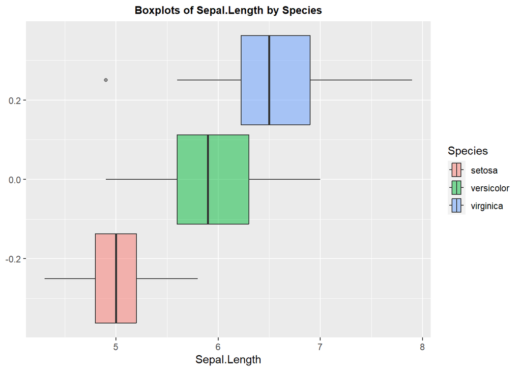

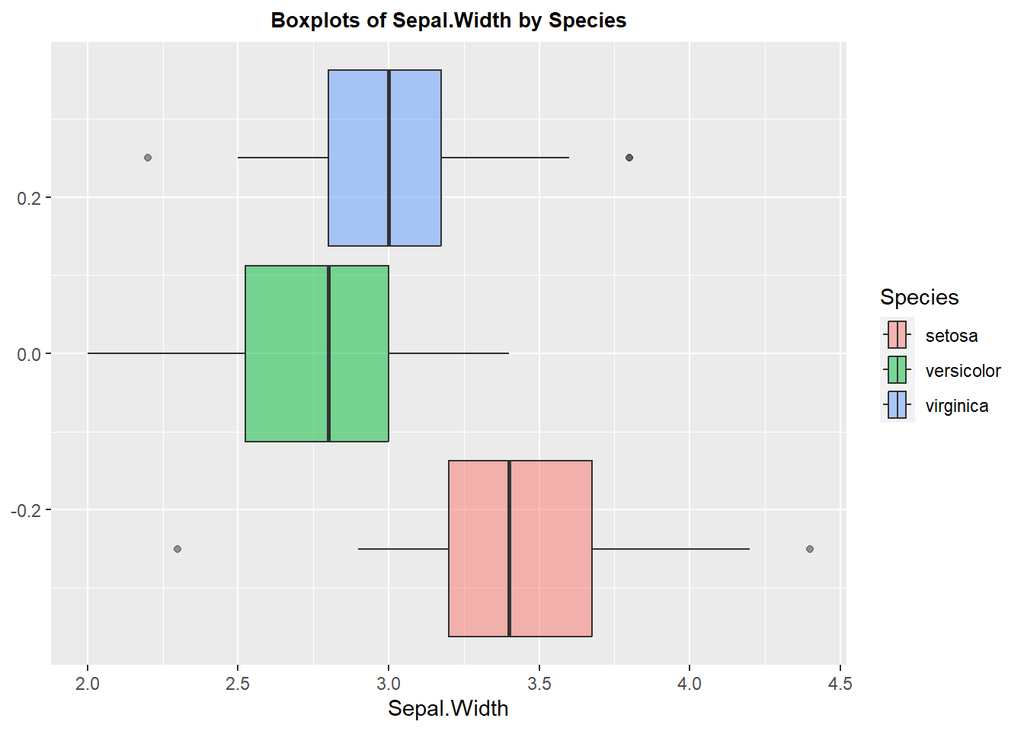

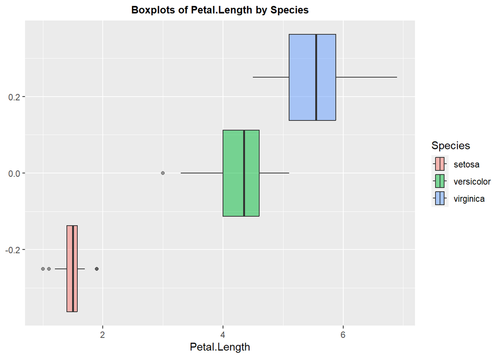

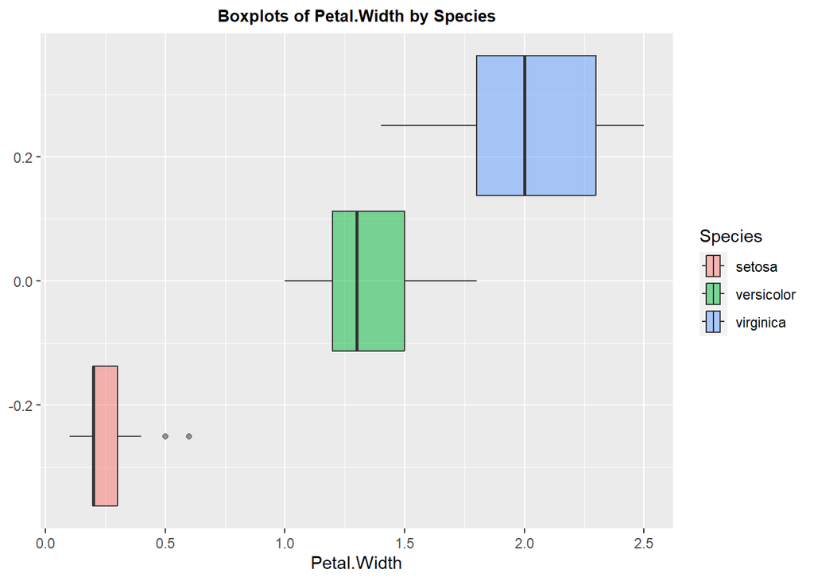

```r
for (i in 1:4){
  plot <- ggplot(iris, aes(x = iris[,i], fill = Species)) + geom_boxplot(alpha = 0.5) + ggtitle(paste0("Boxplots of ", names(iris)[i], " by Species")) + theme(plot.title = element_text(hjust = 0.5, face="bold", size = 10)) + xlab(names(iris[i]))
  print(plot)
}
```

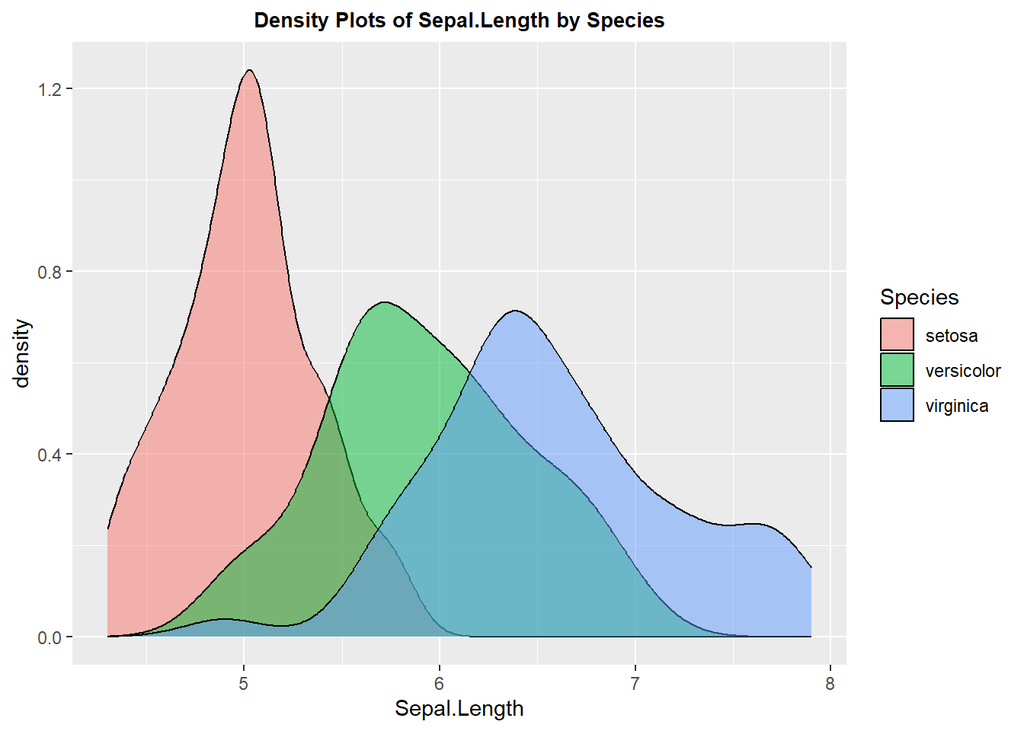

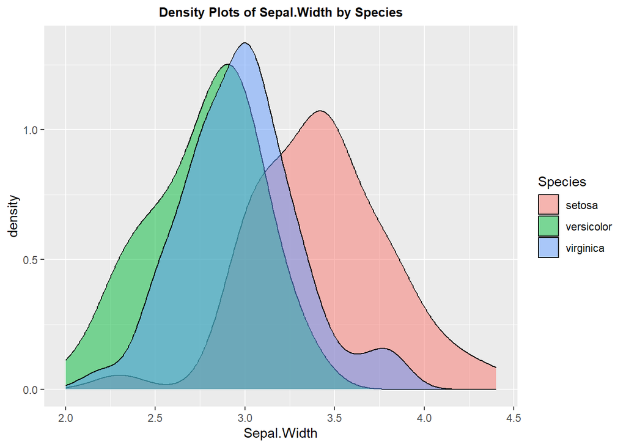

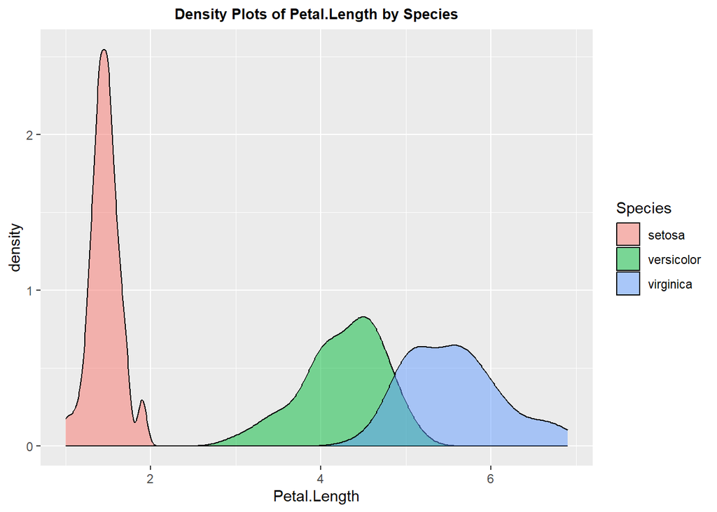

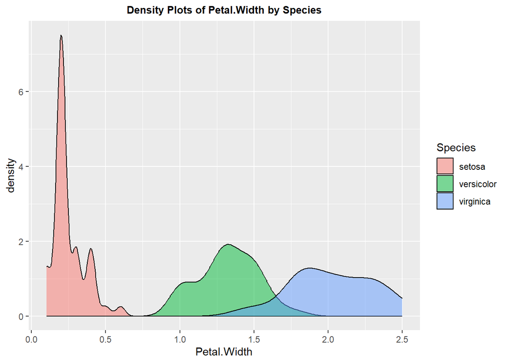

```r
for (i in 1:4){
  plot <- ggplot(iris, aes(x = iris[,i], fill = Species)) + geom_density(alpha = 0.5) + ggtitle(paste0("Density Plots of ", names(iris)[i], " by Species")) + theme(plot.title = element_text(hjust = 0.5, face="bold", size = 10)) + xlab(names(iris[i]))
  print(plot)
}
```

```r
# filtering a separate dataframe for just Specie Setosa

Setosa <- iris %>% filter(Species == "setosa")
Setosa
```

[output not shown]

[output cut: 36 more lines]

```r
# correlation matrix for specie
cor(Setosa[,1:4])
```

```
##              Sepal.Length Sepal.Width Petal.Length Petal.Width
## Sepal.Length    1.0000000   0.7425467    0.2671758   0.2780984
## Sepal.Width     0.7425467   1.0000000    0.1777000   0.2327520
## Petal.Length    0.2671758   0.1777000    1.0000000   0.3316300
## Petal.Width     0.2780984   0.2327520    0.3316300   1.0000000
```

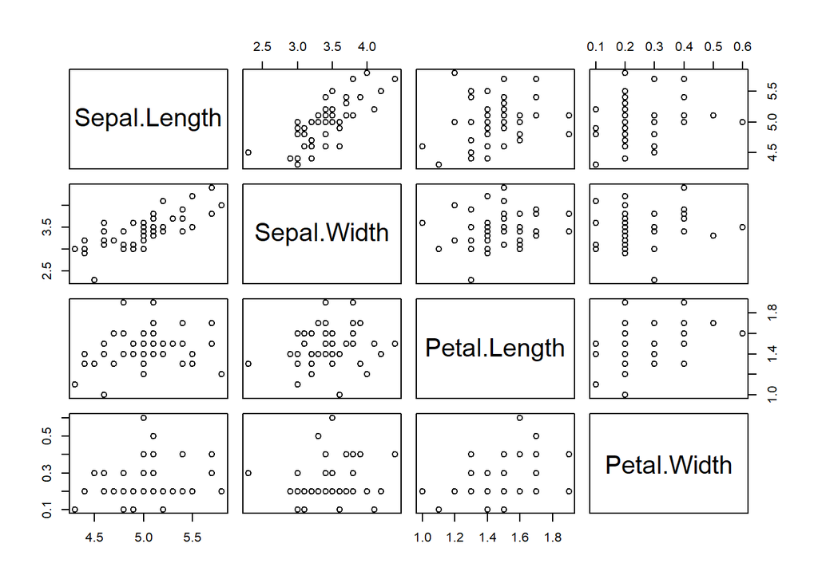

```r
# pairplot for setosa specie
pairs(Setosa[,1:4])
```

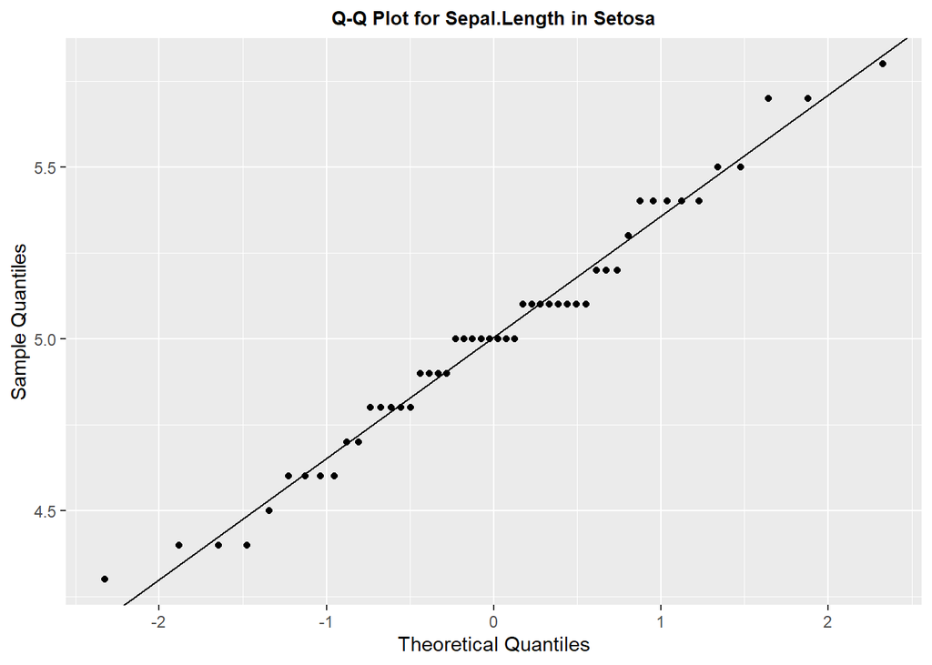

```
## [1] "Correlation coefficient for Sepal.Length in Setosa is: 0.9905"
```

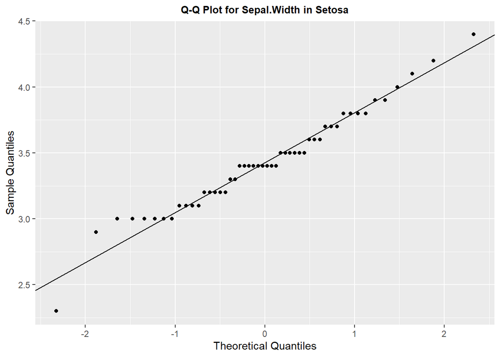

```
## [1] "Correlation coefficient for Sepal.Width in Setosa is: 0.983"
```

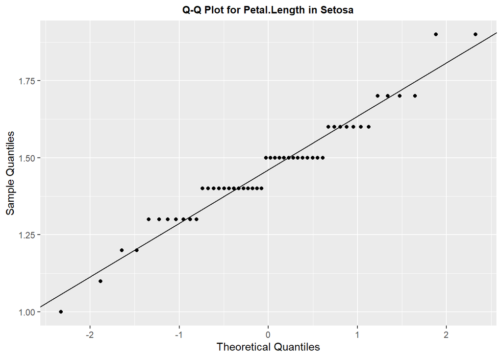

```
## [1] "Correlation coefficient for Petal.Length in Setosa is: 0.9754"
```

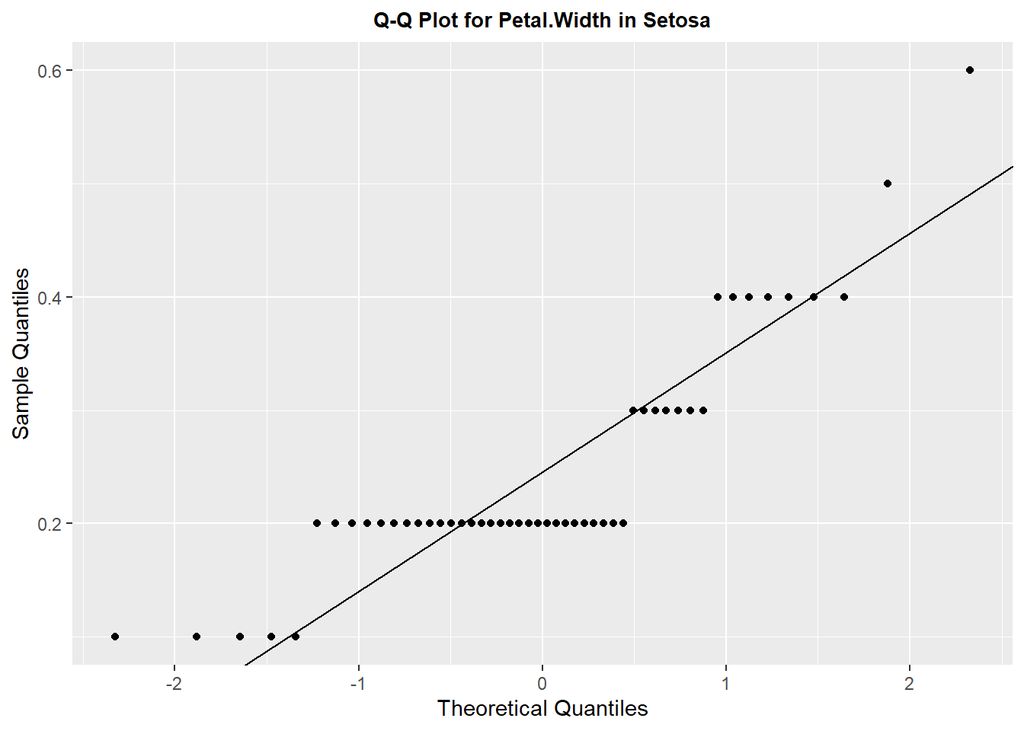

```
## [1] "Correlation coefficient for Petal.Width in Setosa is: 0.8928"
```

```r
# Loop over columns 1 to 4 and create Q-Q plot and correlation test
for (i in 1:4) {
  colname <- names(Setosa)[i] # Get column name
  data <- Setosa %>% select(colname) # Select column data
  data <- data %>% arrange(.data[[colname]]) # Sort data in ascending order
  data <- data %>% mutate(probability = (row_number() - 0.5) / nrow(Setosa), # Add probability column
                          standard_quantiles = qnorm(probability)) # Add standard quantiles column

  # Plot Q-Q plot using ggplot2
  plot <- ggplot(data, aes(x = standard_quantiles, y = !!sym(colname))) +
    geom_point() + geom_abline(intercept = mean(Setosa[[colname]]), slope = sd(Setosa[[colname]])) + labs(x = "Theoretical Quantiles", y = "Sample Quantiles") +
    ggtitle(paste("Q-Q Plot for", colname, "in Setosa")) + theme(plot.title = element_text(hjust = 0.5, face="bold", size = 10))
  print(plot)

  # Correlation test for normality
  rQ <- sum((data[[colname]] - mean(data[[colname]])) * (data$standard_quantiles - mean(data$standard_quantiles))) /
    sqrt((sum((data[[colname]] - mean(data[[colname]]))^2)) * (sum((data$standard_quantiles - mean(data$standard_quantiles))^2)))

  print(paste("Correlation coefficient for", colname, "in Setosa is:", round(rQ, 4)))
}
```

- At a significance level of 0.05 and sample size n=50, if we refer to the critical points for the Q-Q plot correlation coefficient test for normality table, we realise that the entry is 0.9768. Since the correlation coefficient for Sepal.length and Sepal.Width in Setosa is greater than 0.9768,we do not reject the hypothesis of normality.
- Meanwhile, Correlation coefficient for Petal.Length and Petal.Width in Setosa is less than 0.9768. So we reject the hypothesis of normality.

```r
# filtering a separate dataframe for just Specie virginica
virginica <- iris %>% filter(Species == "virginica")
virginica
```

```
##    Sepal.Length Sepal.Width Petal.Length Petal.Width   Species
## 1           6.3         3.3          6.0         2.5 virginica
## 2           5.8         2.7          5.1         1.9 virginica
## 3           7.1         3.0          5.9         2.1 virginica
## 4           6.3         2.9          5.6         1.8 virginica
## 5           6.5         3.0          5.8         2.2 virginica
## 6           7.6         3.0          6.6         2.1 virginica
## 7           4.9         2.5          4.5         1.7 virginica
## 8           7.3         2.9          6.3         1.8 virginica
## 9           6.7         2.5          5.8         1.8 virginica
## 10          7.2         3.6          6.1         2.5 virginica
## 11          6.5         3.2          5.1         2.0 virginica
## 12          6.4         2.7          5.3         1.9 virginica
## 13          6.8         3.0          5.5         2.1 virginica
## 14          5.7         2.5          5.0         2.0 virginica
```

[output cut: 36 more lines]

```r
cor(virginica[,1:4])
```

```
##              Sepal.Length Sepal.Width Petal.Length Petal.Width
## Sepal.Length    1.0000000   0.4572278    0.8642247   0.2811077
## Sepal.Width     0.4572278   1.0000000    0.4010446   0.5377280
## Petal.Length    0.8642247   0.4010446    1.0000000   0.3221082
## Petal.Width     0.2811077   0.5377280    0.3221082   1.0000000
```

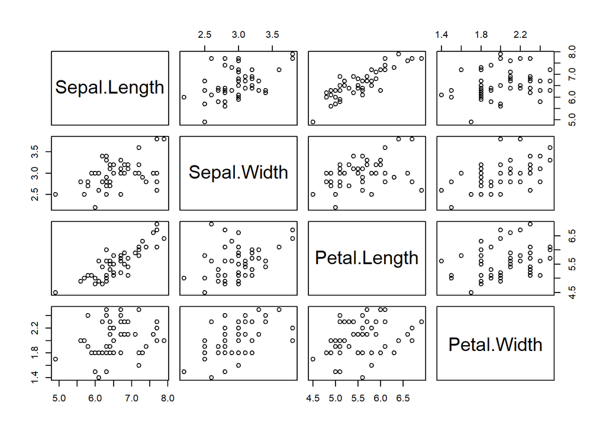

```r
pairs(virginica[,1:4])
```

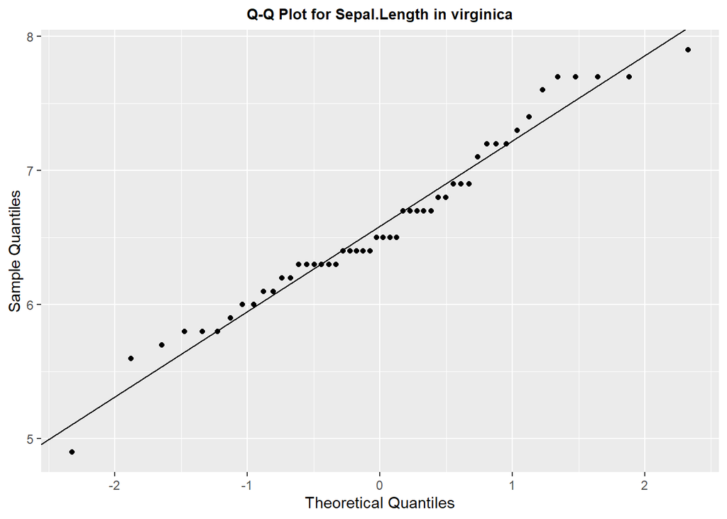

```
## [1] "Correlation coefficient for Sepal.Length in virginica is: 0.9856"
```

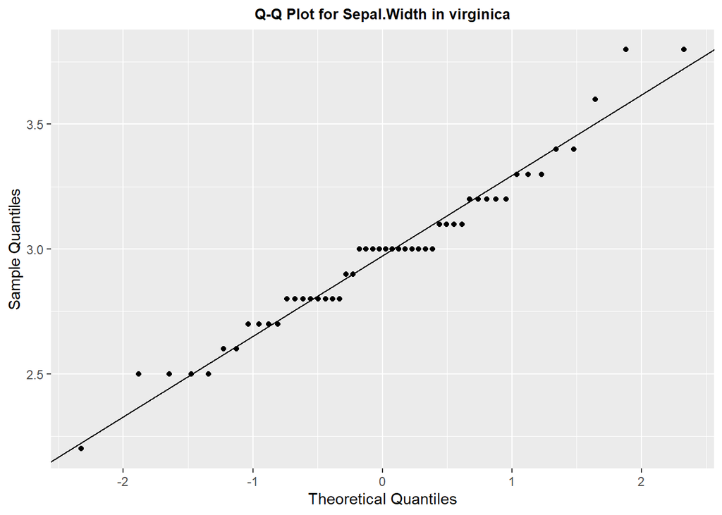

```
## [1] "Correlation coefficient for Sepal.Width in virginica is: 0.9828"
```

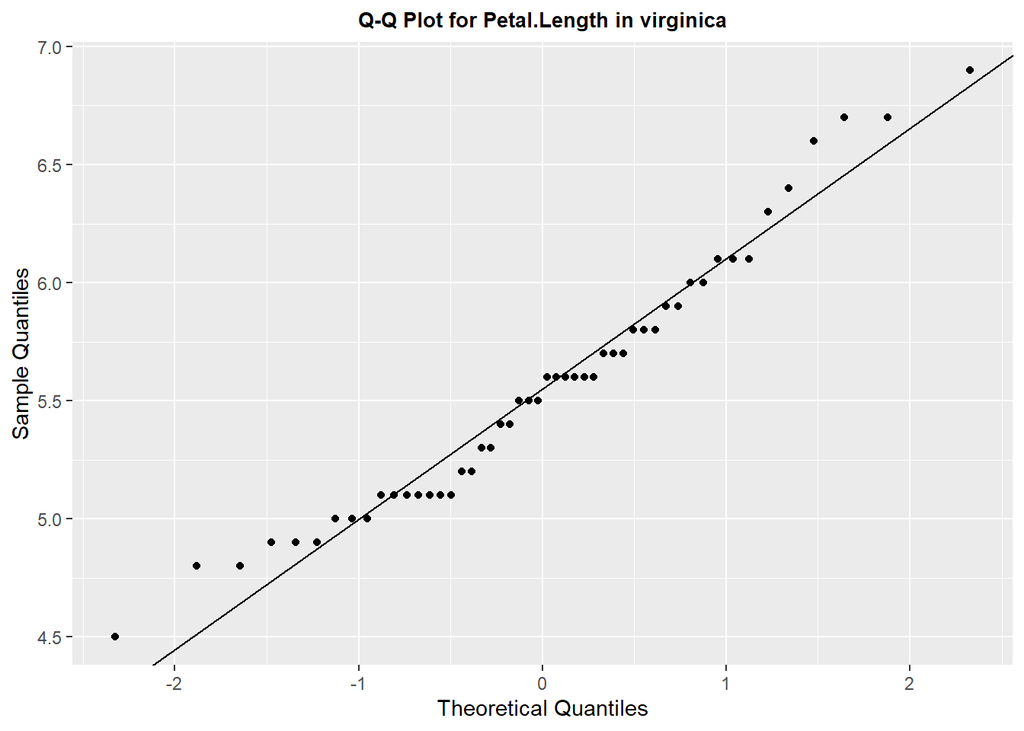

```
## [1] "Correlation coefficient for Petal.Length in virginica is: 0.9821"
```

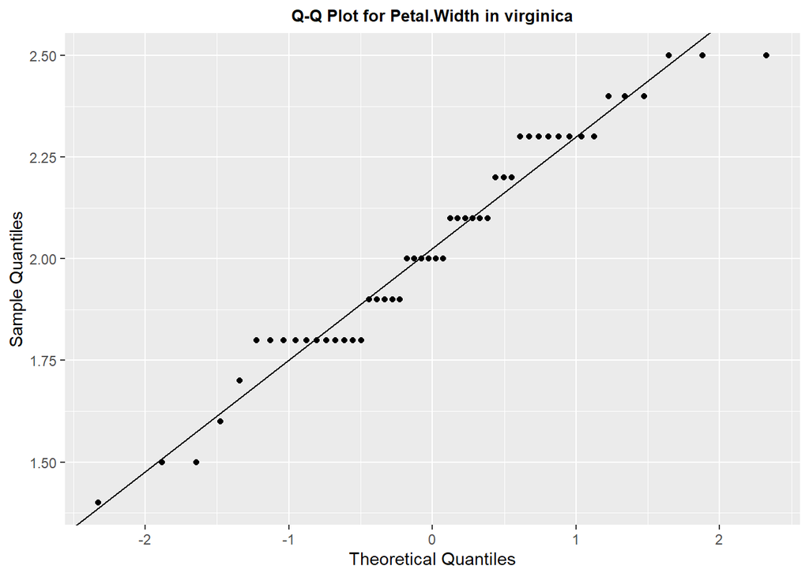

```
## [1] "Correlation coefficient for Petal.Width in virginica is: 0.9819"
```

```r
# Loop over columns 1 to 4 and create Q-Q plot and correlation test
for (i in 1:4) {
  colname <- names(virginica)[i] # Get column name
  data <- virginica %>% select(colname) # Select column data
  data <- data %>% arrange(.data[[colname]]) # Sort data in ascending order
  data <- data %>% mutate(probability = (row_number() - 0.5) / nrow(virginica), # Add probability column
                          standard_quantiles = qnorm(probability)) # Add standard quantiles column

  # Plot Q-Q plot using ggplot2
  plot <- ggplot(data, aes(x = standard_quantiles, y = !!sym(colname))) +
    geom_point() + geom_abline(intercept = mean(virginica[[colname]]), slope = sd(virginica[[colname]])) + labs(x = "Theoretical Quantiles", y = "Sample Quantiles") +
    ggtitle(paste("Q-Q Plot for", colname, "in virginica")) + theme(plot.title = element_text(hjust = 0.5, face="bold", size = 10))
  print(plot)

  # Correlation test for normality
  rQ <- sum((data[[colname]] - mean(data[[colname]])) * (data$standard_quantiles - mean(data$standard_quantiles))) /
    sqrt((sum((data[[colname]] - mean(data[[colname]]))^2)) * (sum((data$standard_quantiles - mean(data$standard_quantiles))^2)))

  print(paste("Correlation coefficient for", colname, "in virginica is:", round(rQ, 4)))
}
```

- At a significance level of 0.05 and sample size n=50, if we refer to the critical points for the Q-Q plot correlation coefficient test for normality table, we realise that the entry is 0.9768. Since the correlation coefficient for all variables in virginica are greater than 0.9768,we do not reject the hypothesis of normality.

```r
# filtering a separate dataframe for just Specie versicolor
versicolor <- iris %>% filter(Species == "versicolor")
versicolor
```

```
##    Sepal.Length Sepal.Width Petal.Length Petal.Width    Species
## 1           7.0         3.2          4.7         1.4 versicolor
## 2           6.4         3.2          4.5         1.5 versicolor
## 3           6.9         3.1          4.9         1.5 versicolor
## 4           5.5         2.3          4.0         1.3 versicolor
## 5           6.5         2.8          4.6         1.5 versicolor
## 6           5.7         2.8          4.5         1.3 versicolor
## 7           6.3         3.3          4.7         1.6 versicolor
## 8           4.9         2.4          3.3         1.0 versicolor
## 9           6.6         2.9          4.6         1.3 versicolor
## 10          5.2         2.7          3.9         1.4 versicolor
## 11          5.0         2.0          3.5         1.0 versicolor
## 12          5.9         3.0          4.2         1.5 versicolor
## 13          6.0         2.2          4.0         1.0 versicolor
## 14          6.1         2.9          4.7         1.4 versicolor
```

[output cut: 36 more lines]

```r
cor(versicolor[,1:4])
```

```
##              Sepal.Length Sepal.Width Petal.Length Petal.Width
## Sepal.Length    1.0000000   0.5259107    0.7540490   0.5464611
## Sepal.Width     0.5259107   1.0000000    0.5605221   0.6639987
## Petal.Length    0.7540490   0.5605221    1.0000000   0.7866681
## Petal.Width     0.5464611   0.6639987    0.7866681   1.0000000
```

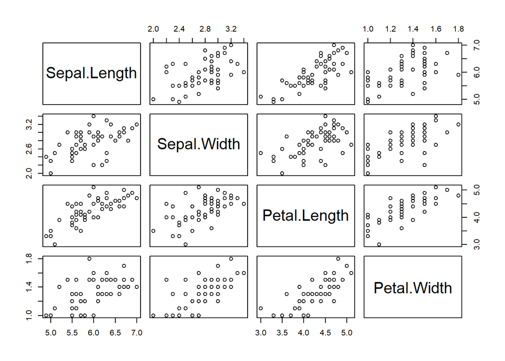

```r
pairs(versicolor[,1:4])
```

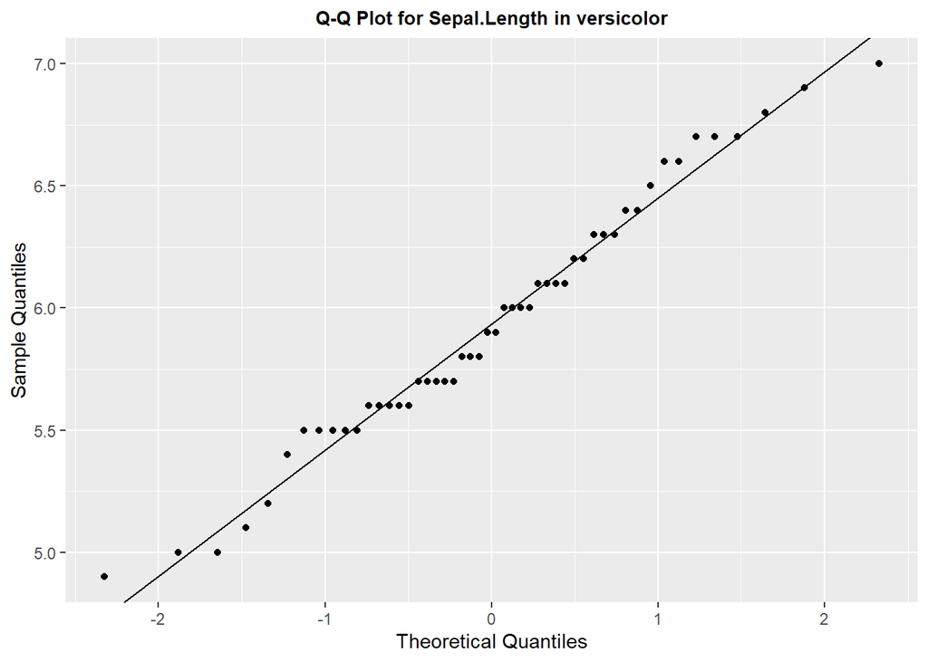

```
## [1] "Correlation coefficient for Sepal.Length in versicolor is: 0.9911"
```

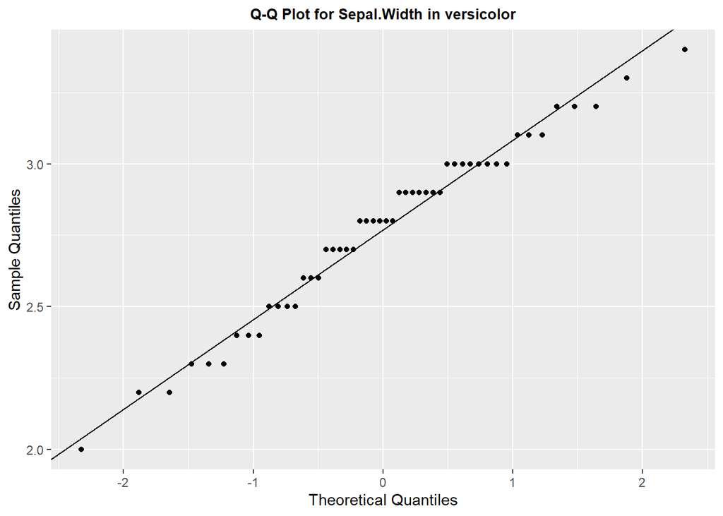

```
## [1] "Correlation coefficient for Sepal.Width in versicolor is: 0.9879"
```

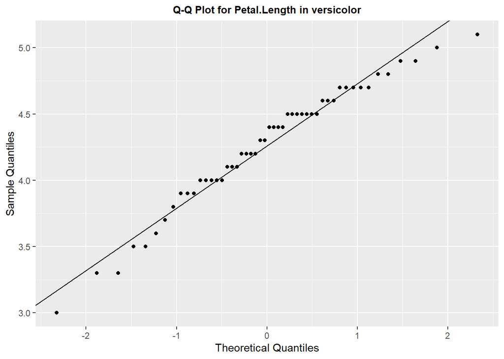

```
## [1] "Correlation coefficient for Petal.Length in versicolor is: 0.9837"
```

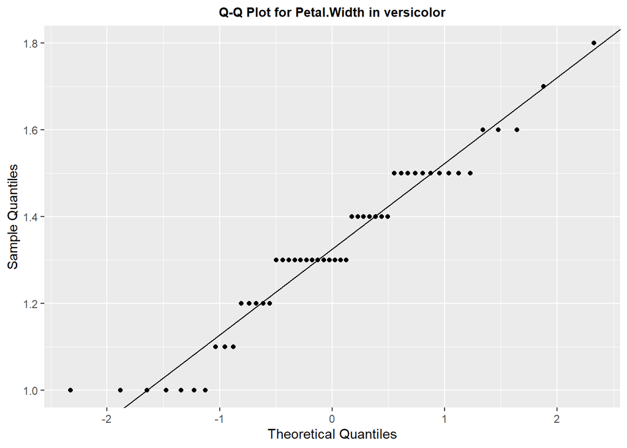

```
## [1] "Correlation coefficient for Petal.Width in versicolor is: 0.9755"
```

```r
# Loop over columns 1 to 4 and create Q-Q plot and correlation test
for (i in 1:4) {
  colname <- names(versicolor)[i] # Get column name
  data <- versicolor %>% select(colname) # Select column data
  data <- data %>% arrange(.data[[colname]]) # Sort data in ascending order
  data <- data %>% mutate(probability = (row_number() - 0.5) / nrow(versicolor), # Add probability column
                          standard_quantiles = qnorm(probability)) # Add standard quantiles column

  # Plot Q-Q plot using ggplot2
  plot <- ggplot(data, aes(x = standard_quantiles, y = !!sym(colname))) +
    geom_point() + geom_abline(intercept = mean(versicolor[[colname]]), slope = sd(versicolor[[colname]])) + labs(x = "Theoretical Quantiles", y = "Sample Quantiles") +
    ggtitle(paste("Q-Q Plot for", colname, "in versicolor")) + theme(plot.title = element_text(hjust = 0.5, face="bold", size = 10))
  print(plot)

  # Correlation test for normality
  rQ <- sum((data[[colname]] - mean(data[[colname]])) * (data$standard_quantiles - mean(data$standard_quantiles))) /
    sqrt((sum((data[[colname]] - mean(data[[colname]]))^2)) * (sum((data$standard_quantiles - mean(data$standard_quantiles))^2)))

  print(paste("Correlation coefficient for", colname, "in versicolor is:", round(rQ, 4)))
}
```

- At a significance level of 0.05 and sample size n=50, if we refer to the critical points for the Q-Q plot correlation coefficient test for normality table, we realise that the entry is 0.9768. Since the correlation coefficient for Sepal.length, Sepal.Width and Petal.Length in versicolor is greater than 0.9768,we do not reject the hypothesis of normality.
- Meanwhile, Correlation coefficient for Petal.Width in versicolor is less than 0.9768. So we reject the hypothesis of normality.

UNIVARIATE NORMALITY TEST

The Shapiro-Wilk test is a univariate test for normality, which means it can only be used to test the normality of one variable at a time. The iris dataset has four variables (sepal length, sepal width, petal length, and petal width), so we cannot use the Shapiro-Wilk test on the entire dataset. We can, however, use it on each variable individually to test for normality. If the p-value is less than the significance level (commonly set at 0.05), we reject the null hypothesis and conclude that the sample does not come from a normal distribution.

```r
# shapiro-Wilk test for Setosa Specie

shapiro.test(Setosa$Sepal.Length)
```

```
##
##  Shapiro-Wilk normality test
##
## data:  Setosa$Sepal.Length
## W = 0.9777, p-value = 0.4595
```

```r
shapiro.test(Setosa$Sepal.Width)
```

```
##
##  Shapiro-Wilk normality test
##
## data:  Setosa$Sepal.Width
## W = 0.97172, p-value = 0.2715
```

```r
shapiro.test(Setosa$Petal.Length)
```

```
##
##  Shapiro-Wilk normality test
##
## data:  Setosa$Petal.Length
## W = 0.95498, p-value = 0.05481
```

```r
shapiro.test(Setosa$Petal.Width)
```

```
##
##  Shapiro-Wilk normality test
##
## data:  Setosa$Petal.Width
## W = 0.79976, p-value = 8.659e-07
```

Using the Shapiro-Wilk test, the p_value for setosa Petal.Width is less than 0.05, so we reject the null hypothesis. There is less than a 5% chance that the deviation from normality was due to random sampling. Meanwhile the p values for the other variables (Sepal.Length, Sepal.Width and Petal.Length) are greater than 0.05 which means that the sample may come from a random distribution.

```r
# Shapiro-Wilk test for virginica specie

shapiro.test(virginica$Sepal.Length)
```

```
##
##  Shapiro-Wilk normality test
##
## data:  virginica$Sepal.Length
## W = 0.97118, p-value = 0.2583
```

```r
shapiro.test(virginica$Sepal.Width)
```

```
##
##  Shapiro-Wilk normality test
##
## data:  virginica$Sepal.Width
## W = 0.96739, p-value = 0.1809
```

```r
shapiro.test(virginica$Petal.Length)
```

```
##
##  Shapiro-Wilk normality test
##
## data:  virginica$Petal.Length
## W = 0.96219, p-value = 0.1098
```

```r
shapiro.test(virginica$Petal.Width)
```

```
##
##  Shapiro-Wilk normality test
##
## data:  virginica$Petal.Width
## W = 0.95977, p-value = 0.08695
```

- Using the Shapiro-Wilk test, none of the p-values for the virginica specie for the different variables is less than 0.05, so we cannot reject the null hypothesis and conclude that the sample may come from a random distribution.

```r
# Shapiro-Wilk test for versicolor specie

shapiro.test(versicolor$Sepal.Length)
```

```
##
##  Shapiro-Wilk normality test
##
## data:  versicolor$Sepal.Length
## W = 0.97784, p-value = 0.4647
```

```r
shapiro.test(versicolor$Sepal.Width)
```

```
##
##  Shapiro-Wilk normality test
##
## data:  versicolor$Sepal.Width
## W = 0.97413, p-value = 0.338
```

```r
shapiro.test(versicolor$Petal.Length)
```

```
##
##  Shapiro-Wilk normality test
##
## data:  versicolor$Petal.Length
## W = 0.966, p-value = 0.1585
```

```r
shapiro.test(versicolor$Petal.Width)
```

```
##
##  Shapiro-Wilk normality test
##
## data:  versicolor$Petal.Width
## W = 0.94763, p-value = 0.02728
```

Using the Shapiro-Wilk test, the p_value for versicolor Petal.Width is less than 0.05, so we reject the null hypothesis. There is less than a 5% chance that the deviation from normality was due to random sampling. Meanwhile the p values for the other variables (Sepal.Length, Sepal.Width and Petal.Length) are greater than 0.05.

The Anderson-Darling test is a statistical test used to assess whether a sample of data comes from a known probability distribution, such as the normal distribution. The null hypothesis of the test is that the sample comes from the specified distribution, and a low p-value indicates that the null hypothesis should be rejected in favor of an alternative hypothesis that the sample does not come from the specified distribution.

```r
library(nortest)

# Anderson-Darling test for setosa specie

ad.test(Setosa$Sepal.Length)
```

```
##
##  Anderson-Darling normality test
##
## data:  Setosa$Sepal.Length
## A = 0.40799, p-value = 0.3352
```

```r
ad.test(Setosa$Sepal.Width)
```

```
##
##  Anderson-Darling normality test
##
## data:  Setosa$Sepal.Width
## A = 0.49096, p-value = 0.2102
```

```r
ad.test(Setosa$Petal.Length)
```

```
##
##  Anderson-Darling normality test
##
## data:  Setosa$Petal.Length
## A = 1.0073, p-value = 0.01079
```

```r
ad.test(Setosa$Petal.Width)
```

```
##
##  Anderson-Darling normality test
##
## data:  Setosa$Petal.Width
## A = 4.7148, p-value = 7.437e-12
```

Using the Anderson-Darling Test, the p_value for setosa Petal.Width and Petal.Length is less than 0.05, so we reject the null hypothesis. There is less than a 5% chance that the deviation from normality was due to random sampling. Meanwhile the p values for the other variables (Sepal.Length and Sepal.Width) are greater than 0.05 which means that the sample may come from a random distribution.

```r
# Anderson-Darling test for virginica specie

ad.test(virginica$Sepal.Length)
```

```
##
##  Anderson-Darling normality test
##
## data:  virginica$Sepal.Length
## A = 0.55164, p-value = 0.1475
```

```r
ad.test(virginica$Sepal.Width)
```

```
##
##  Anderson-Darling normality test
##
## data:  virginica$Sepal.Width
## A = 0.61821, p-value = 0.1018
```

```r
ad.test(virginica$Petal.Length)
```

```
##
##  Anderson-Darling normality test
##
## data:  virginica$Petal.Length
## A = 0.60896, p-value = 0.1074
```

```r
ad.test(virginica$Petal.Width)
```

```
##
##  Anderson-Darling normality test
##
## data:  virginica$Petal.Width
## A = 0.73879, p-value = 0.05076
```

- Using the Anderson-Darling test, none of the p-values for the virginica specie for the different variables is less than 0.05, so we cannot reject the null hypothesis and conclude that the sample may come from a random distribution

```r
# Anderson-Darling test for versicolor specie

ad.test(versicolor$Sepal.Length)
```

```
##
##  Anderson-Darling normality test
##
## data:  versicolor$Sepal.Length
## A = 0.36084, p-value = 0.4333
```

```r
ad.test(versicolor$Sepal.Width)
```

```
##
##  Anderson-Darling normality test
##
## data:  versicolor$Sepal.Width
## A = 0.55976, p-value = 0.1406
```

```r
ad.test(versicolor$Petal.Length)
```

```
##
##  Anderson-Darling normality test
##
## data:  versicolor$Petal.Length
## A = 0.55506, p-value = 0.1446
```

```r
ad.test(versicolor$Petal.Width)
```

```
##
##  Anderson-Darling normality test
##
## data:  versicolor$Petal.Width
## A = 0.95685, p-value = 0.01443
```

- Using the Anderson-Darling Test, the p_value for versicolor Petal.Width is less than 0.05, so we reject the null hypothesis. There is less than a 5% chance that the deviation from normality was due to random sampling. Meanwhile the p values for the other variables (Sepal.Length, Sepal.Width and Petal.Length) are greater than 0.05 which means that the sample may come from a random distribution.